# Targeted panel variant analysis: SEQC2 Sample B

Burning Rock OncoScreen Plus (520 genes), library SampleB_BRP1_ST28_LIB3

Author

Alperen Korkmaz

## Overview

This report summarises a variant-calling analysis of a public SEQC2 reference sample (Sample B, a normal male cell line) sequenced with the Burning Rock OncoScreen Plus panel. Reads were trimmed (fastp), aligned to hg19 (bwa mem), duplicate-marked (samtools), checked for coverage (mosdepth), and variants were called, normalised and filtered with bcftools, then annotated with SnpEff. The full pipeline is in `scripts/variant_call_pipeline.sh`.

## 1. Sequencing and alignment QC

```r
# --- fastp: read counts before/after trimming --------------------------------
# fastp counts R1 and R2 separately, so read pairs = reads / 2
fastp <- fromJSON(res("fastp", paste0(sample, "_fastp.json")))
raw_pairs   <- fastp$summary$before_filtering$total_reads / 2
clean_pairs <- fastp$summary$after_filtering$total_reads / 2

# --- samtools flagstat: alignment numbers ------------------------------------
# Each line starts with a count, e.g. "77781850 + 0 primary mapped (99.96% : N/A)".
# flag_count() returns the count on the first line that matches a pattern.
flagstat <- readLines(res("alignment", paste0(sample, ".flagstat.txt")))
flag_count <- function(pattern) {
  line <- flagstat[str_detect(flagstat, pattern)][1]
  as.numeric(str_extract(line, "^\\d+"))
}
primary         <- flag_count(" primary$")
primary_mapped  <- flag_count(" primary mapped \\(")
properly_paired <- flag_count(" properly paired \\(")
primary_dups    <- flag_count(" primary duplicates$")

# --- samtools markdup: estimated library size --------------------------------
# Lines look like "ESTIMATED_LIBRARY_SIZE: 19244688"
markdup <- readLines(res("alignment", paste0(sample, ".markdup_stats.txt")))
library_size <- markdup |>
  str_subset("^ESTIMATED_LIBRARY_SIZE:") |>
  str_extract("\\d+$") |>
  as.numeric()

# --- mosdepth: mean depth over the target regions ----------------------------
cov_summary <- read_tsv(res("coverage", paste0(sample, ".mosdepth.summary.txt")))
mean_target_depth <- cov_summary |>
  filter(chrom == "total_region") |>
  pull(mean)

# --- on-target rate (computed in the pipeline with samtools view -L) ---------
on_target <- read_tsv(res("coverage", paste0(sample, ".on_target.tsv")))
on_target_rate <- on_target$on_target_reads / on_target$total_reads

# --- mosdepth thresholds: fraction of target bases at each depth -------------
# Columns: #chrom, start, end, region, then one column per threshold
thresholds <- read_tsv(res("coverage", paste0(sample, ".thresholds.bed.gz")))
target_bp  <- sum(thresholds$end - thresholds$start)
pct_100x   <- sum(thresholds$`100X`)  / target_bp
pct_500x   <- sum(thresholds$`500X`)  / target_bp
```

```r
pct   <- function(x) scales::percent(x, accuracy = 0.01)
fmt_n <- function(x) scales::comma(x)

qc <- tribble(
  ~Metric,                                     ~Value,
  "Raw read pairs",                            fmt_n(raw_pairs),
  "Read pairs after trimming (fastp)",         paste0(fmt_n(clean_pairs), " (", pct(clean_pairs / raw_pairs), ")"),
  "Mapped (primary reads)",                    pct(primary_mapped / primary),
  "Properly paired",                           pct(properly_paired / primary),
  "Duplicate rate",                            pct(primary_dups / primary),
  "Estimated library size (unique fragments)", fmt_n(library_size),
  "On-target rate (unique reads)",             pct(on_target_rate),
  "Mean depth over targets",                   paste0(round(mean_target_depth), "x"),
  "Target bases at ≥100x",                     pct(pct_100x),
  "Target bases at ≥500x",                     pct(pct_500x)
)

kable(qc, caption = "Sequencing, alignment and coverage summary")
```

Sequencing, alignment and coverage summary

| Metric | Value |
| --- | --- |
| Raw read pairs | 39,406,874 |
| Read pairs after trimming (fastp) | 38,906,133 (98.73%) |
| Mapped (primary reads) | 99.96% |
| Properly paired | 99.62% |
| Duplicate rate | 57.05% |
| Estimated library size (unique fragments) | 19,244,688 |
| On-target rate (unique reads) | 77.34% |
| Mean depth over targets | 1493x |
| Target bases at ≥100x | 99.67% |
| Target bases at ≥500x | 96.72% |

The library was sequenced to roughly twice its estimated size (38,906,133 read pairs for about 19,244,688 unique fragments), which explains the high duplicate rate: further sequencing would have added little new information. After removing duplicates and reads with mapping quality below 20, the targets were still covered at a mean depth of 1493x.

## 2. Coverage

```r
regions <- read_tsv(res("coverage", paste0(sample, ".regions.bed.gz")),
                    col_names = c("chrom", "start", "end", "gene", "depth")) |>
  mutate(length = end - start)

gene_cov <- regions |>
  group_by(gene) |>
  summarise(
    n_regions  = n(),
    length_bp  = sum(length),
    mean_depth = sum(depth * length) / sum(length)
  ) |>
  arrange(mean_depth)

kable(head(gene_cov, 10), digits = 0,
      caption = "The 10 genes with the lowest mean depth")
```

The 10 genes with the lowest mean depth

| gene | n_regions | length_bp | mean_depth |
| --- | --- | --- | --- |
| CRLF2 | 12 | 2640 | 0 |
| HIST2H3C | 1 | 420 | 0 |
| CALR | 2 | 360 | 365 |
| PMAIP1 | 1 | 180 | 386 |
| EIF4A2 | 1 | 180 | 491 |
| ZRSR2 | 1 | 180 | 522 |
| VEGFB | 1 | 180 | 525 |
| PAK3 | 12 | 2400 | 556 |
| EIF1AX | 1 | 180 | 587 |
| CDKN1C | 3 | 840 | 632 |

The mean depth of each gene is a length-weighted average over its target regions, so long regions count more than short ones. Two genes, CRLF2 and HIST2H3C, have no usable coverage; the reason is explained below the low-coverage table.

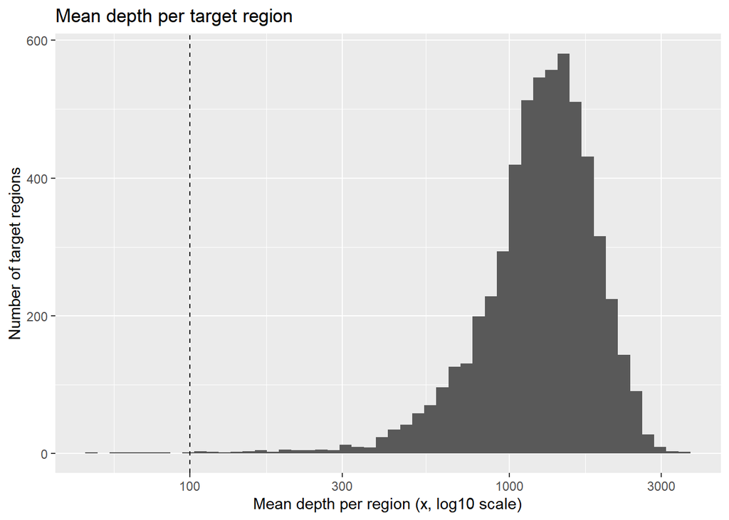

```r
ggplot(regions, aes(x = depth)) +
  geom_histogram(bins = 50) +
  scale_x_log10() +
  geom_vline(xintercept = 100, linetype = "dashed") +
  labs(x = "Mean depth per region (x, log10 scale)",
       y = "Number of target regions",
       title = "Mean depth per target region")
```

The median depth of a target region is 1,302x. The dashed line marks 100x. Regions with a depth of 0x cannot be drawn on a logarithmic axis (log10(0) is undefined), so they are missing from this histogram; they are listed in the table below.

```r
low_cov <- regions |>
  filter(depth < 100) |>
  arrange(depth)

kable(low_cov, digits = 0, caption = "Target regions with mean depth below 100x")
```

Target regions with mean depth below 100x

| chrom | start | end | gene | depth | length |
| --- | --- | --- | --- | --- | --- |
| chr1 | 149812313 | 149812733 | HIST2H3C | 0 | 420 |
| chrX | 1314833 | 1315073 | CRLF2 | 0 | 240 |
| chrX | 1317368 | 1317608 | CRLF2 | 0 | 240 |
| chrX | 1321218 | 1321458 | CRLF2 | 0 | 240 |
| chrX | 1325288 | 1325528 | CRLF2 | 0 | 240 |
| chrX | 1327659 | 1327839 | CRLF2 | 0 | 180 |
| chrX | 1331397 | 1331577 | CRLF2 | 0 | 180 |
| chrY | 1264833 | 1265073 | CRLF2 | 0 | 240 |
| chrY | 1267368 | 1267608 | CRLF2 | 0 | 240 |
| chrY | 1271218 | 1271458 | CRLF2 | 0 | 240 |
| chrY | 1275288 | 1275528 | CRLF2 | 0 | 240 |
| chrY | 1277659 | 1277839 | CRLF2 | 0 | 180 |
| chrY | 1281397 | 1281577 | CRLF2 | 0 | 180 |
| chr9 | 139440117 | 139440297 | NOTCH1 | 49 | 180 |
| chr6 | 35420296 | 35420596 | FANCE | 60 | 300 |
| chr19 | 41725249 | 41725429 | AXL | 65 | 180 |
| chr9 | 101569944 | 101570064 | GALNT12 | 68 | 120 |
| chr19 | 33792810 | 33792930 | CEBPA | 79 | 120 |
| chr19 | 33792639 | 33792759 | CEBPA | 83 | 120 |
| chr19 | 17947889 | 17948069 | JAK3 | 99 | 180 |

20 of 5,757 target regions have a mean depth below 100x. The regions of CRLF2 and HIST2H3C are at 0x even though reads are present. CRLF2 lies in the pseudoautosomal region PAR1, whose sequence is identical on chrX and chrY. Reads from this region align equally well to both chromosomes and therefore receive a mapping quality (MAPQ) of 0. HIST2H3C belongs to a family of near-identical histone genes, with the same effect. Because reads with MAPQ below 20 were excluded, these regions appear empty: in one CRLF2 region, 4,032 unique reads were present without the MAPQ filter and none with it. Variants in these two genes cannot be called with this pipeline. The other low-coverage regions still reach at least 49x, which is enough for germline calling.

## 3. Variant calling and filtering

```r
# Return the number at the end of the first line matching a pattern,
# e.g. "SN  0  number of records:  1283" -> 1283
stats_value <- function(lines, pattern) {
  line <- lines[str_detect(lines, pattern)][1]
  as.numeric(str_extract(line, "\\d+$"))
}

# Read one bcftools stats file and return one table row
read_stats <- function(stage) {
  lines <- readLines(res("variants", paste0(sample, ".", stage, ".stats.txt")))

  # TSTV line split into columns: 1 = "TSTV", 2 = id, 3 = ts, 4 = tv, 5 = ts/tv
  tstv <- str_split(str_subset(lines, "^TSTV"), "\t")[[1]]

  tibble(
    stage   = stage,
    records = stats_value(lines, "number of records:"),
    snps    = stats_value(lines, "number of SNPs:"),
    indels  = stats_value(lines, "number of indels:"),
    ts_tv   = as.numeric(tstv[5])
  )
}

stages <- c("raw", "normalized", "filtered", "pass")
funnel <- map(stages, read_stats) |> list_rbind()

kable(funnel, digits = 2, caption = "Variant counts at each pipeline stage")
```

Variant counts at each pipeline stage

| stage | records | snps | indels | ts_tv |
| --- | --- | --- | --- | --- |
| raw | 1283 | 1133 | 150 | 2.30 |
| normalized | 1339 | 1133 | 206 | 2.30 |
| filtered | 1246 | 1121 | 125 | 2.32 |
| pass | 1246 | 1121 | 125 | 2.32 |

**Note on indel calling.** By default, `bcftools mpileup` looks at no more than 250 reads per position when calling indels. At a depth of about 1,500x this silently skipped almost all indels: the first run reported only 2. Raising the limit (`-L 10000`) gave 150 indels, with no change in the SNV calls.

## 4. Variant characteristics

```r
variants <- read_tsv(
  res("variants", paste0(sample, ".variants.tsv")),
  col_names = c("chrom", "pos", "ref", "alt", "filter", "qual",
                "gt", "dp", "vaf", "ann")
)

variants <- variants |>
  mutate(
    # ANN can hold several annotations separated by ","; SnpEff sorts them
    # by severity, so the first one is the most damaging.
    first_ann = str_extract(ann, "^[^,]+"),
    effect    = str_split_i(first_ann, "\\|", 2),
    impact    = str_split_i(first_ann, "\\|", 3),
    gene      = str_split_i(first_ann, "\\|", 4),
    protein   = str_split_i(first_ann, "\\|", 11),
    type      = if_else(nchar(ref) == 1 & nchar(alt) == 1, "SNP", "indel"),
    zygosity  = if_else(gt == "1/1", "hom", "het")
  ) |>
  select(-ann, -first_ann)
```

```r
# Reference sequence around each variant (10 bp before, 20 bp after)
context <- read_tsv(
  res("variants", paste0(sample, ".context.tsv")),
  col_names = c("region", "context")
) |>
  mutate(
    chrom   = str_extract(region, "chr[^:]+"),
    pos     = as.numeric(str_extract(region, "(?<=:)\\d+")) + 10,
    context = toupper(context)
  ) |>
  distinct(chrom, pos, context)

# Homopolymer (8+ identical bases) or dinucleotide repeat (5+ copies)
repeat_pattern <- "A{8,}|C{8,}|G{8,}|T{8,}|([ACGT]{2})\\1{4,}"

variants <- variants |>
  left_join(context, by = c("chrom", "pos")) |>
  mutate(in_repeat = str_detect(context, repeat_pattern))
```

```r
pass <- variants |> filter(filter == "PASS")
```

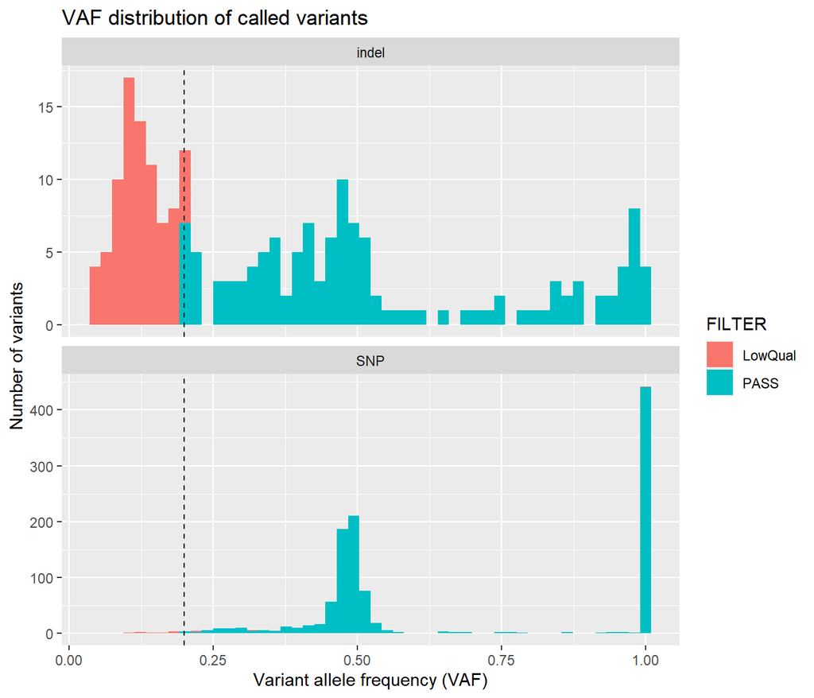

```r
ggplot(variants, aes(x = vaf, fill = filter)) +
  geom_histogram(bins = 50) +
  geom_vline(xintercept = 0.2, linetype = "dashed") +
  facet_wrap(~ type, ncol = 1, scales = "free_y") +
  labs(x = "Variant allele frequency (VAF)", y = "Number of variants",
       fill = "FILTER", title = "VAF distribution of called variants")
```

For a germline sample, VAF is expected near 0.5 for heterozygous variants (one of two copies) and near 1.0 for homozygous variants (both copies). The SNVs follow this pattern. Calls labelled `LowQual` lie mostly below the VAF threshold of 0.2 (dashed line), and most of them are indels.

```r
pass |>
  dplyr::count(type, zygosity) |>
  pivot_wider(names_from = zygosity, values_from = n) |>
  mutate(het_hom_ratio = het / hom) |>
  kable(digits = 2, caption = "Zygosity of PASS variants")
```

Zygosity of PASS variants

| type | het | hom | het_hom_ratio |
| --- | --- | --- | --- |
| SNP | 671 | 450 | 1.49 |
| indel | 90 | 35 | 2.57 |

The heterozygous-to-homozygous ratio of PASS SNVs is a plausible value for a human germline sample.

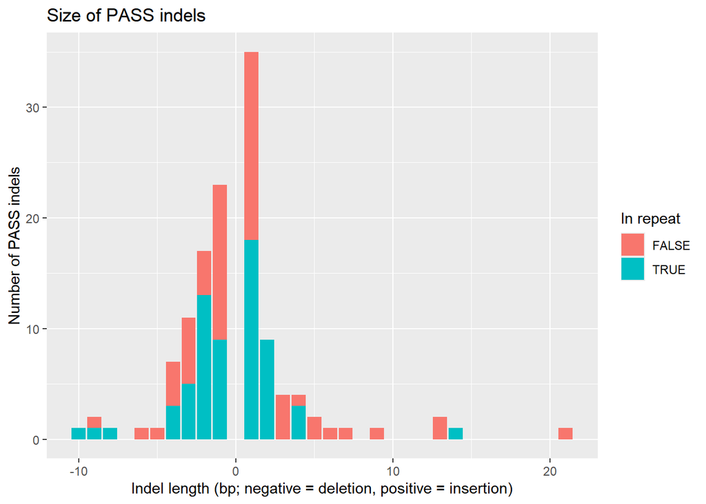

```r
pass |>
  filter(type == "indel") |>
  mutate(indel_length = nchar(alt) - nchar(ref)) |>
  ggplot(aes(x = indel_length, fill = in_repeat)) +
  geom_bar() +
  labs(x = "Indel length (bp; negative = deletion, positive = insertion)",
       y = "Number of PASS indels", fill = "In repeat",
       title = "Size of PASS indels")
```

```r
variants |>
  dplyr::count(filter, type, in_repeat) |>
  kable(caption = "Variants in homopolymer / dinucleotide repeats, by filter status")
```

Variants in homopolymer / dinucleotide repeats, by filter status

| filter | type | in_repeat | n |
| --- | --- | --- | --- |
| LowQual | SNP | FALSE | 11 |
| LowQual | SNP | TRUE | 1 |
| LowQual | indel | FALSE | 3 |
| LowQual | indel | TRUE | 78 |
| PASS | SNP | FALSE | 1104 |
| PASS | SNP | TRUE | 17 |
| PASS | indel | FALSE | 61 |
| PASS | indel | TRUE | 64 |

Most PASS indels are only one or two bases long. To see where they occur, the reference sequence around each variant (10 bp before to 20 bp after) was checked for a homopolymer of at least 8 identical bases or a dinucleotide repeat of at least 5 copies. 69% of indels but only 1.6% of SNVs fall in such repeats.

PCR and short-read sequencing are error-prone in repeats: the polymerase can “slip” and add or lose one repeat unit (stutter). During variant calling, several repeat sites showed three alleles at once, which is impossible for one diploid sample, and the extra alleles reached 10–30% VAF. A VAF threshold of 0.2 therefore cannot remove all of them. At the same time, repeats are genuinely highly variable between people. A variant in a repeat is therefore less reliable, not necessarily false.

## 5. Annotated variants

All PASS variants are listed below, sorted by predicted impact (HIGH, MODERATE, LOW, MODIFIER). The boxes above the columns can be used to search, for example for a gene name.

```r
impact_levels <- c("HIGH", "MODERATE", "LOW", "MODIFIER")

pass |>
  mutate(impact = factor(impact, levels = impact_levels)) |>
  arrange(impact, chrom, pos) |>
  select(gene, chrom, pos, ref, alt, effect, impact, protein,
         dp, vaf, zygosity, in_repeat) |>
  datatable(filter = "top", rownames = FALSE,
            options = list(pageLength = 15, scrollX = TRUE)) |>
  formatRound("vaf", 2)
```

| gene | chrom | pos | ref | alt | effect | impact | protein | dp | vaf | zygosity | in_repeat |
| --- | --- | --- | --- | --- | --- | --- | --- | --- | --- | --- | --- |
| ATM | chr11 | 108121410 | C | CT | splice_acceptor_variant&amp;intron_variant | HIGH |  | 963 | 0.349711 | het | True |
| NCOR1 | chr17 | 16068343 | G | A | stop_gained | HIGH | p.Arg190* | 2007 | 0.445441 | het | False |
| MAP3K14 | chr17 | 43364293 | C | CG | frameshift_variant | HIGH | p.Arg219fs | 1633 | 0.969994 | hom | False |
| MST1R | chr3 | 49940697 | CG | C | frameshift_variant | HIGH | p.Gly116fs | 2601 | 0.509419 | het | False |
| VEGFC | chr4 | 177605081 | CTCA | C | splice_acceptor_variant&amp;splice_donor_variant&amp;intron_variant | HIGH |  | 1562 | 0.964789 | hom | False |
| KMT2C | chr7 | 151945071 | G | GT | frameshift_variant&amp;stop_gained | HIGH | p.Tyr816fs | 4505 | 0.274584 | het | False |
| PRKDC | chr8 | 48805816 | A | AG | frameshift_variant | HIGH | p.Phe1244fs | 1202 | 0.981697 | hom | False |
| TNFRSF14 | chr1 | 2488153 | A | G | missense_variant | MODERATE | p.Lys17Arg | 1339 | 0.512323 | het | False |
| TNFRSF14 | chr1 | 2494330 | G | A | missense_variant | MODERATE | p.Val241Ile | 1408 | 0.479403 | het | False |
| SPEN | chr1 | 16256007 | T | C | missense_variant | MODERATE | p.Leu1091Pro | 1974 | 0.500507 | het | False |

[output cut: 1236 more lines]

Impact categories are SnpEff predictions. For each variant the first annotation is shown, which is the most severe one across all transcripts and may not refer to the main (canonical) transcript.

The 7 HIGH-impact calls need particular caution:

- one (ATM) is a single-base insertion in a homopolymer at a splice acceptor site, with a VAF of 0.35;
- one (KMT2C) has a VAF of 0.28, which is unusual for a germline variant;
- three (PRKDC, MAP3K14, VEGFC) appear homozygous. Loss of both copies of these genes is not expected in a healthy cell line; for example, biallelic loss of PRKDC causes severe combined immunodeficiency. Possible explanations are positions where the hg19 reference itself carries a rare allele, or effects that are severe only in a minor transcript.

None of these calls was validated, so they should not be read as damaging variants.

## 6. Limitations

- **Germline calling only.** bcftools assumes a diploid sample, and variants with VAF < 0.2 are filtered out. The pipeline is not suitable for low-frequency (somatic or mosaic) variants.
- **Regions that cannot be called.** CRLF2 (PAR1) and HIST2H3C have no reads with MAPQ ≥ 20. Masking the PAR region of chrY in the reference would recover CRLF2.
- **Indels in repeats.** Indels in homopolymers and short tandem repeats are unreliable with 150 bp reads. The repeat flag used here is simple: its window size and thresholds were chosen by hand, and it does not detect repeats with units longer than two bases.
- **QUAL and depth filters.** At about 1,500x, QUAL values saturate (most calls fall between 220 and 228), and the depth threshold of 20 almost never applies. In practice the VAF threshold did most of the filtering.
- **Annotation.** Only the most severe SnpEff annotation is reported, and HIGH-impact calls were not checked against population databases such as gnomAD.
- **No truth-set comparison.** The calls were not compared with the SEQC2 reference call set, so precision and sensitivity are unknown. This is the most important next step.
- **One library.** Only one of the four technical replicates (LIB3) was analysed.